# Introducing xts and zoo objects

```r
knitr::opts_chunk$set(warning = F, message = F,
                      fig.width = 5, fig.height = 5)
```

```r
library(dplyr)
library(xts)
```

xts is an eXtensive Time Series.They have the main objects called “zoo” objects= A matrix object + a vector of times. This means an observation of the objects in the matrix in the times in that vector.

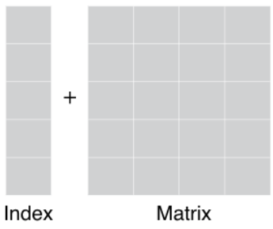

A matrix of objects are observed in that vector of times in index

XTS = matrix + index

Matrix of obsevations

```r
x <- matrix(1:4, ncol=2, nrow = 2)
x
```

Index (vector) of times These must be a time object.

```r
idx <- as.Date(c("2015-01-01", "2015-02-01"))
idx
```

XTS

```r
X <- xts(x,              #x must be matrix or a vector
         order.by = idx) #idx must be increasing time object same lenght with x
X
```

Birinci gün vektöründe 1 ile 3’üncü gözlemler, ikinci gün vektöründe 2 ile 4’üncü gözlemler yapılmış.

```r
xts(x = NULL,            #an object containing the time series data
    order.by = index(x), #order by vector of times in increasing order of time
    frequency = NULL,    #
    unique = TRUE,       #force times to be unique
    tzone = Sys.getenv("TZ"), #set the time zone
    )
```

Interestingly, if you take a subset from the matrix, xts will preserve the timestamps if there are any.

XTS içinden matrixi `zoo::coredata(x, fmt=F)`, dateleri almak için `zoo::index(x)` kullanılır.

# Examples

```r
data <- rnorm(15) #create a vector of random 15 numbers

dates <- seq(as.Date("2020-01-01"), #create  a sequence of dates from
             length = 15,           #for 15 times
             by = "days")           #in days (15 days)


ex <- xts(x = data,            #create a xts from the data matrix
          order.by = dates,    #order by the dates as index
          bday = as.POSIXct("2020-01-01")) #special bday marker in that day

ex
```

Extract the data and the date

```r
data_extract <- coredata(ex)
data_extract

date_extract <- index(ex)
date_extract
```

## Importing, exporting and converting time series

Sunspot verisini `as.xts()` ile xts’e çevirebiliriz.

```r
sunspots_xts <- as.xts(sunspots)
sunspots_xts
```

Bir dosyayı okurken de `as.xts(read.csv())` formatıyla doğrudan xts olarak yükleyebiliriz.

```r
# Create data by reading tmp_file
data <- read.csv(tmp_file)

# Convert data into xts
xts(data, order.by = as.Date(rownames(dat), "%m/%d/%Y"))

# Read tmp_file using read.zoo and as.xts
data_zoo <- read.zoo(tmp_file, index.column = 0, sep = ",", format = "%m/%d/%Y")

# Read tmp_file using read.zoo and as.xts
data_xts <- as.xts(data_zoo)
```

## The ISO-8601 standard

Bu standart metodda soldan başlanarak sağa doğru tarih büyükten küçüğe yazılır. “YYYY-MM-DD-HH-MM-SS”

```r
A["20090825"]       ## Aug 25, 2009
A["201203/201212"]  ## Mar to Dec 2012
A["/201601"]        ## Up to and including January 2016

# Extract all data between 8AM and 10AM
morn_2010 <- irreg["T08:00/T10:00"]

# Extract the observations for January 13th, 2010
morn_2010["2010-01-13"]

#Ama tüm tarihler data["YYYY-MM-DD"] olarak daha net anlaşılır.
```

## Row selection with time objects

POSIXct günü ve saati tutan bir date objesi türüdür.

Head ve tail fonksiyonlarındaki gibi ilk ve son n veriyi `xts::first()` ve `xts::last()` ile alabiliriz.

```r
first(PerformanceAnalytics::edhec[, "Funds of Funds"],
      "3 months")
```

```r
last(as.xts(austres), n=4)
```

```r
last(as.xts(austres), "3 years")
```

```r
first(as.xts(austres), "-20 years") #everything but the first 20 years
```

```r
# Extract the first three days of the second week of temps
first(last(first(dat, "2 weeks"), "1 week"), "3 days")
```

```r
# Add a to b, and fill all missing rows of b with 0
a + merge(b, index(a), fill = 0)

# Add a to b and fill NAs with the last observation
a + merge(b, index(a), fill = na.locf)
```

## Merging time series

[figure not shown]

Merge() function

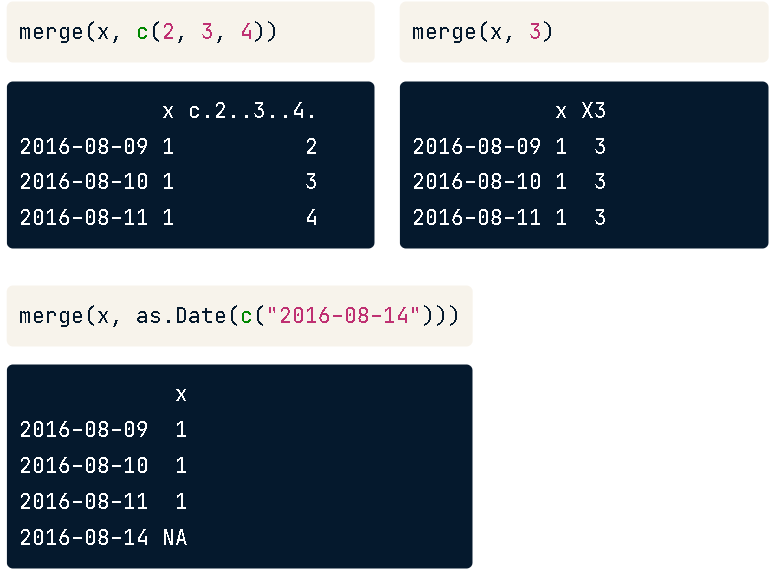

Merge() function

rbind() only excepts dates

```r
# Perform an inner join of a and b
merge(a, b, join = "inner")

# Perform a left-join of a and b, fill missing values with 0
merge(a, b, join = "left", fill = 0)
```

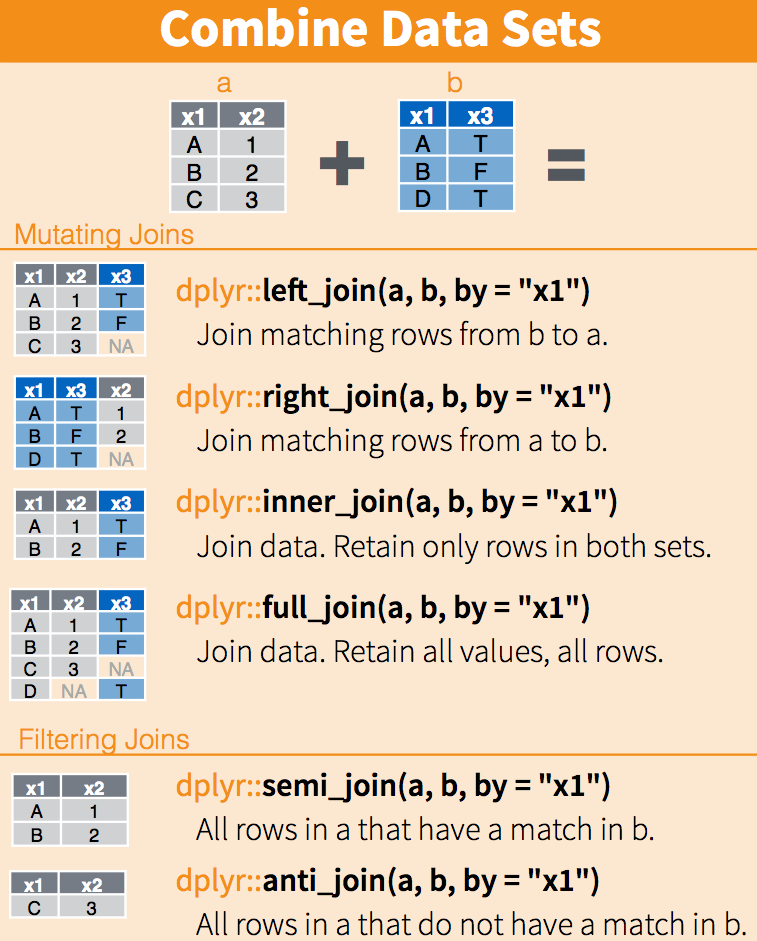

Join mantığı